# Final_Report

2023-03-29

## R Markdown

The Home effect is a widely recognised effect in sports, wherein the team playing at Home is observed to perform better than expected. In this report, we will investigate the effect of Covid on this Home advantage effect. There are many hypotheses as to why it exists. Some are related to the venue, which includes location, weather or a sense of familiarity. Other Hypotheses include special rules which apply to the home team or even the presence of fans, which can have an effect on the player’s performance.

The Data-set is the number of goals scored in each match in the English Premier League from the 2018-19 season to 2021-22 season. For each match, we have information regarding the team which is playing at Home and the team that is playing away.

We define the 2018-19 and the truncated 2019-90 seasons as pre-covid, the 2020-21 season to be in covid, when the fans were not allowed to be in stadiums, and the 2021-2022 season as post-covid.

## Exploration of the Data

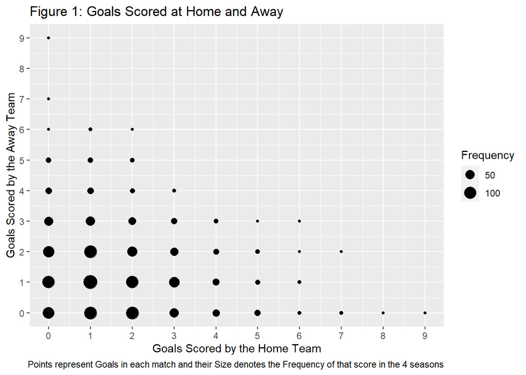

In Figure 1, we see that most matches end up with at least one goal by each team and the number of matches where we have more than 3 goals for both the teams is much lower. Also, we remark that even though the figure looks symmetric about the diagonal, in principle, there is no reason why it has to be so. We have plotted each match once, and there is no reason to expect that there is another match wherein the scores of the teams are reversed.

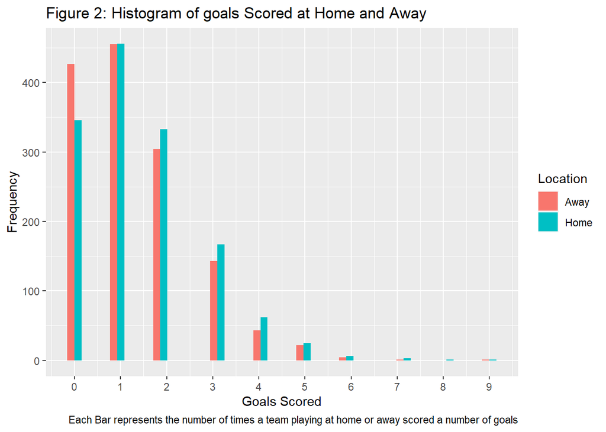

## Objectives

The first question of interest is if the Home advantage effect persisted through covid, that is, if it persisted even when the fans were not in the stadium. This is supposed to be indicative of the effect of the Home Advantage, whether the fans somehow have an intangible effect on the morale and the psychological state of the team, and consequently, on their performance.

The second question of interest is to quantify this Home Advantage, and to examine the effect of covid on it.

## Model

For each match, we model the number of goals scored by the home team and away team separately as independent Poisson variables. For each team, we define to coefficients, the Attack and Defence capabilities, and use them to model the number of goals scored. For the team playing at home, we allow an indicator variable to determine the effect of the Home Advantage. To allow us to quantify the effect of Covid and its effect on Home advantage, we have ‘Covid’ as Factor Variable with three levels ‘Before’, ‘In’ and ‘After’ and the interaction term for Covid and Home advantage.

We compare this model to a model without the interaction term to determine if there was an effect of Covid on the Home advantage effect. In our opinion, it is necessary to include a term for Covid in this smaller model to incorporate the possibility that the playing styles of the teams had changed due to covid, possibly due to the players trying to avoid each other subconsciously.

Thus, if $X_{i,j}$ is the score of Team $i$ when it played against team $j$, the model we have is as follows -
$$X_i \sim Poi(\mu_{(i,j)}).$$

Here,

$$ln(\mu_{(i,j)}) =
\alpha_i - \beta_j + C_{\text{Home}} \cdot \mathbf{1}_{\text{Home}} +
C_{\text{Covid}} \cdot \mathbf{1}_{\text{Covid}}+ D_{\text{Home } \star
\text{ Covid}}$$

where $\alpha_i$ denotes the ‘Attack’ capability of Team $i$ and $\beta_j$ denotes the ‘Defence” capability of Team $j$’ and the indicator for Home is 1 if theam $i$ is at home and 0 otherwise.

Now, the smaller model is equivalent to the case when the coefficients for the interaction terms are all zero.

## Results and Discussion

We run a model-submodel test to determine the usefulness of the interaction term. We observed that the p-value is 0.057 which suggests that the interaction is significant at the 90 % confidence level.

We see selected coefficients from the model in Table 1.

Table 1: Some Coefficients

| Term | Mean | SD |
| --- | --- | --- |
| Home1 | 0.19 | 0.05 |
| CovidIn | 0.06 | 0.06 |
| CovidLater | 0.01 | 0.06 |
| Home1:CovidIn | -0.19 | 0.08 |
| Home1:CovidLater | -0.05 | 0.08 |

We see that the effect of the Home advantage had disappeared in Covid, and continues to be slightly depressed after covid. This sugests that the presence of Fans is strongly related to the Home Advantage Effect.

## Diagnostics

We see from Figure 1 the data contains too many small values, i.e. values less than 3, and thus the conclusions from Likelihood theory may be suspect. For the same reason, we do not expect the residuals to be informative and we asses the suitability of the model by using a bootstrap test.

First, we sample parameters from their respective confidence intervals and then use them to make predictions regarding the number of Goals. Next, we fit the model and compare the residual deviance of the model fitted to the bootstrap data and the residual deviance of the model fitted to the actual data.

We observe that the p-value is quite large(0.71) and thus, we can say confidently that the model is able to adequately capture the underlying patterns in the data and the inference that Covid reduced the Home advantage in valid. This is in spite of our assumption that the scores in each match are independent realisations of Poisson Random Variables. Lastly, we tried to do this same procedure for Teams which were in all the seasons of the league and found out that the effect size was similar with a somewhat reduced but still arge p value. Thus, we can conclude that the Home effect did indeed reduce during covid.

## Appendix

We remark that due to theoretical reasons, we need to fit this model with the intercept. If we do not, the likelihood theory from the multinomial perspective of looking at the contingency table does not lead to accurate coefficients in the model.

Table 2 : All Coefficients

|  | Estimate | Std. Error |
| --- | --- | --- |
| (Intercept) | 0.28 | 0.11 |
| AttackAston Villa | -0.13 | 0.11 |
| AttackBournemouth | -0.24 | 0.13 |
| AttackBrentford | -0.23 | 0.16 |
| AttackBrighton | -0.42 | 0.11 |
| AttackBurnley | -0.45 | 0.11 |
| AttackCardiff | -0.60 | 0.19 |
| AttackChelsea | 0.06 | 0.09 |
| AttackCrystal Palace | -0.31 | 0.10 |
| AttackEverton | -0.23 | 0.10 |
| AttackFulham | -0.68 | 0.14 |
| AttackHuddersfield | -1.03 | 0.22 |
| AttackLeeds | -0.12 | 0.12 |
| AttackLeicester | 0.05 | 0.09 |
| AttackLiverpool | 0.31 | 0.09 |
| AttackMan City | 0.41 | 0.09 |
| AttackMan United | 0.04 | 0.09 |
| AttackNewcastle | -0.36 | 0.10 |
| AttackNorwich | -0.75 | 0.16 |
| AttackSheffield United | -0.74 | 0.16 |
| AttackSouthampton | -0.27 | 0.10 |
| AttackTottenham | 0.09 | 0.09 |
| AttackWatford | -0.39 | 0.12 |
| AttackWest Brom | -0.49 | 0.18 |
| AttackWest Ham | -0.09 | 0.10 |
| AttackWolves | -0.36 | 0.10 |
| DefenceAston Villa | 0.17 | 0.11 |
| DefenceBournemouth | 0.34 | 0.12 |
| DefenceBrentford | 0.14 | 0.16 |
| DefenceBrighton | 0.06 | 0.11 |
| DefenceBurnley | 0.19 | 0.10 |
| DefenceCardiff | 0.37 | 0.14 |
| DefenceChelsea | -0.18 | 0.11 |
| DefenceCrystal Palace | 0.12 | 0.10 |
| DefenceEverton | 0.12 | 0.10 |
| DefenceFulham | 0.34 | 0.12 |
| DefenceHuddersfield | 0.45 | 0.14 |
| DefenceLeeds | 0.34 | 0.12 |
| DefenceLeicester | 0.06 | 0.11 |
| DefenceLiverpool | -0.47 | 0.12 |
| DefenceMan City | -0.42 | 0.12 |
| DefenceMan United | 0.07 | 0.11 |
| DefenceNewcastle | 0.19 | 0.10 |
| DefenceNorwich | 0.46 | 0.12 |
| DefenceSheffield United | 0.06 | 0.13 |
| DefenceSouthampton | 0.34 | 0.10 |
| DefenceTottenham | -0.09 | 0.11 |
| DefenceWatford | 0.31 | 0.11 |
| DefenceWest Brom | 0.48 | 0.14 |
| DefenceWest Ham | 0.13 | 0.10 |
| DefenceWolves | -0.03 | 0.11 |
| Home1 | 0.19 | 0.05 |
| CovidIn | 0.06 | 0.06 |
| CovidLater | 0.01 | 0.06 |
| Home1:CovidIn | -0.19 | 0.08 |
| Home1:CovidLater | -0.05 | 0.08 |